[figure not shown]

**Masterarbeit** · Department für Wirtschafts- und Rechtswissenschaften  
1. Gutachter: Prof. Dr. Cristian Huse · 2. Gutachter: [N.N.]

# Demand Estimation with Unstructured Product Data

Evidence from Amazon’s Toothpaste Market

Burak Uzun

July 2026

Abstract

Merger simulation hinges on correctly measuring substitution patterns, yet the nesting structures used in practice are typically built from coarse labels such as brand identity. This paper asks whether product representations extracted from unstructured listing content – images and text encoded with CLIP (Radford et al. 2021) – define substitution patterns better than brand labels do. Using an ASIN-by-quarter panel of the Amazon US toothpaste market around Colgate-Palmolive’s 2020 acquisition of the natural-brand hello, we estimate three nested-logit demand models via the Berry (1994) linearisation that differ only in how nests are assigned: no nesting, brand nesting, and nesting by k-means clusters of CLIP image-and-text embeddings. CLIP-based nesting fits demand best and, critically, reduces the share of economically implausible negative implied marginal costs from 8.6% to 1.7%. Because CLIP places hello and Colgate in different clusters, the implied diversion between the merging parties is small: the simulated merger price effect for hello falls from +1.23% under plain logit to +0.40% under CLIP nesting. Placebo tests confirm that any cross-firm nesting can repair the cost side. What is distinctive to CLIP is that it also fits demand better than 95% of random partitions and yields a merger counterfactual free of the spurious diversion those partitions introduce. The results suggest embedding-based nests are a practical, replicable tool for antitrust analysis when conventional product characteristics are unavailable.

**Keywords:** demand estimation; unstructured data; CLIP embeddings; nested logit; merger simulation; antitrust.

**JEL codes:** C55, D12, L13, L41, L81.

# 1 Introduction

## 1.1 Motivation

Competition authorities are encountering mergers and analyzing their effects on the market. These mergers typically take the form of an established firm in the market acquiring a relatively small and rapidly growing brand. In an automotive market merger, regulators can observe product characteristics—such as horsepower, fuel consumption, and brand influence—as widely expected, and model substitution effects accordingly. In the case of consumer goods, however, the situation is somewhat different; differentiation here may relate to product names, product descriptions, and packaging/visual elements. It is essential to include these latent factors in the model. However, the primary tools for merger simulation have been developed for structured data labels. Nested Logit models (McFadden, 1978) typically estimate substitution effects by assigning nested categories based on brand names or manually selected segments. When these coarse observable labels misrepresent how consumers perceive products, the resulting substitution patterns and simulated price effects carry that misclassification forward, a problem that has been noted in the merger simulation literature as a source of systematic bias.

Another practical challenge is estimating the price effect in a robust manner. This requires variables on the external cost side (IV); however, online retail data rarely includes this variation. While input cost series vary only over time and are absorbed by quarter fixed effects, Hausman-style competitor price instruments (Hausman 1996) show correlation across markets due to demand shocks. These instrument limitations compound the misspecification problem, and the difficulties caused by an unspecified demand model are well-documented in the literature (Werden and Froeb 1994), motivating later approaches that recover demand structure from product characteristics directly. Underestimating demand elasticity can lead to overestimated Bertrand markups and, consequently, negative marginal costs recovered from the demand side.

## 1.2 Research Objectives

This paper examines whether the differentiation structure of products can be extracted from unstructured data, and whether doing so produces more plausible merger price effects. We can describe this as an empirical study centered around three research questions. First, can nests constructed from product images and text/descriptions identify substitution patterns as well as—or better than— the nests derived from brand identities? Second, to what extent does the estimated merger price effect change when the nesting rule is altered? Third, in a scenario where the missing instrument problem and endogeneity lead to an underestimation of substitutability, resulting in implausibly large markups and, consequently, negative marginal costs, do latent factors derived from unstructured data yield a more plausible economic estimate?

## 1.3 Approach and Contribution

The inability to identify a valid instrument was the primary problem encountered in this paper, which we overcame through a methodological change. To overcome this lack of an instrument and establish a valid model, price elasticity for CPG was calibrated using a meta-analytic finding (Bijmolt, van Heerde, and Pieters 2005).

Another empirical aspect worth noting in the data is Colgate-Palmolive’s acquisition of hello Products LLC, an oral care brand that positions itself as “naturally friendly” in the market. The deal, which was officially announced on January 23, 2020, was completed on January 31, 2020, for $351 million. This provides a clear event date on a quarterly basis (2020Q1) and is included in the data. The ASIN-by-quarter panel data spanning from Q1 2018 to Q3 2022 is one of the empirical advantages enabling us to validate our model using this merger event and test it against simulation.

## 1.4 Structure

In this study, Section 2 addresses discrete choice demand models, their identification, and representation learning. Section 3 discusses industry and market settings while explaining the panel data itself and the process of creating embedding spaces. Section 4 provides a comprehensive overview of the empirical framework, while Section 5 presents the analytical results (coefficient estimates, recovered costs, counterfactual simulations, etc.). The limitations—which we emphasize must be taken into account and that our findings should be interpreted with caution—are discussed in section 6. Finally, the overall discussion is concluded in section 7.

# 2 Related Literature

This study and its contributions are primarily grounded in the literature under three main headings: discrete-choice demand modeling and its application in merger analysis, where standard logit models struggle to capture realistic substitution patterns; the endogeneity problem in demand models, which biases price coefficient estimates; and the identification and calibration of the price variable, as well as the use of product representations in economic modeling and consumer choice studies, where measurement choices directly shape demand estimates.

## 2.1 Discrete Choice Demand and Merger Simulations

The demand framework is derived from the discrete choice literature. The literature shows that logit models can be linearized by inverting market shares (Berry 1994). From there, under Bertrand competition, first-order conditions can be used to invert observed prices and recover marginal costs. The well-known BLP (Berry, Levinsohn, and Pakes 1995) generalized this framework to random-coefficient logit models, which allows for more flexible substitution patterns and is now standard in merger simulation. However, the resulting complex modeling (continuous consumer heterogeneity across product characteristics) made the equation multidimensional and rendered inversion impossible. To overcome this “curse of dimensionality,” a contraction mapping (a fixed-point iteration algorithm) was introduced. This algorithm numerically inverted market share to recover the mean product utility (δ). Thus, once the mean utility was recovered, the effect of unobserved product quality (ξ) could be isolated as a linear residual. However, while the standard logit model is computationally quite advantageous, it suffers from a major drawback, the Independence of Irrelevant Alternatives (IIA) property, which motivates the use of nested logit and random-coefficient models instead. This model is based on the assumption that consumers substitute between products purely in proportion to their market shares, without considering the products’ actual characteristics, which poses serious practical difficulties. While Random Coefficients models break this assumption at the aggregate level by mixing over consumer types, nested logit models relax this rigid assumption by grouping similar products (allowing the unobserved components of utility to be correlated within nests) (Cardell 1997). Comparing RCNL (Random Coefficient Nested Logit), RC (Random Coefficient Logit), and Nested Logit (NL) models using the EU automobile market, Grigolon and Verboven (2014) found that nested logit models can produce estimates close to those of random-coefficient models when well-specified. They demonstrated that nested logit models, which are computationally much cheaper, can produce estimates close to the heterogeneous preference patterns of random-coefficient logit models when well-specified. More directly relevant here, they also found that segmentation via nesting captures discrete market segmentation that continuously measured product characteristics do not capture, which is what makes the nesting structure itself consequential. This makes the choice of nesting structure—the primary focus of our study—a binding constraint. More specifically, nesting choices depend on firm-specific priors (brand, category, or observed characteristics), and the resulting substitution patterns are only as good as those priors. The basic framework for the practical application of these models is outlined in Nevo (2000a). A comprehensive application of the method—encompassing all structural stages such as demand forecasting, margin recovery, and the analysis of competitive scenarios—was successfully demonstrated by Nevo (2000b) in the context of the ready-to-eat breakfast cereal sector, a fast-moving consumer good similar to the toothpaste market.

The merger simulation employs the methodologies developed by Werden and Froeb (1994) and Nevo (2000b) to calculate pre-merger marginal costs, update the ownership structure, and recalculate Bertrand-Nash prices using the damped fixed-point iteration method examined by Morrow and Skerlos (2011), making them a natural fit for a differentiated-product market setting where Bertrand competition is the assumed pricing model. This method enables competition analysis by simulating changes in post-merger market prices. The PyBLP routines developed by Conlon and Gortmaker (2020) form the basis for validating the Bertrand-Nash equilibrium price calculations in this study, confirming that the merger simulation follows current best practices. But can such simulations actually predict the effects of a merger on the market in practice? Various studies (Peters (2006) and Björnerstedt and Verboven (2016)) have shown that in retrospective merger analyses, simulations can predict actual market movements to a large extent or at least partially. For example, in the study by Björnerstedt and Verboven, the actual 40% price increase in the paracetamol segment in Sweden was predicted quite closely (+41.1% under the constant-expenditures nested logit). In addition to this, the placebo analysis in Section 5.6 brings the same approach to a single application—not predictions against realized prices, but the preferred nesting within the space of alternative structures.

## 2.2 Identification and Calibration of Price Sensitivity

In applied industrial organization, price endogeneity is a classic problem (Berry 1994; Berry, Levinsohn, and Pakes 1995), quite common when estimating demand from aggregate market data. In its simplest definition, price endogeneity refers to the correlation between a product’s price and the error term in the model—a term that is unobservable to the econometrician. More specifically, since profit-maximizing firms set higher prices for unobserved, higher-quality products, the price variable becomes correlated with unobserved demand shocks (Nevo 2000a, 2001). Instrumental variables are used to address price endogeneity. However, in this study, the price is not instrumented but is calibrated. In line with the rationale explained in the introduction, well-known solutions such as classical cost shifters, BLP-type differentiation instruments, or other market prices introduced by Hausman (1996) rely on exclusion restrictions that are difficult to justify in a single-category panel dataset on a national platform. Therefore, the price coefficient has been fixed to an exogenous target value instead. This target elasticity value of $-2.62$ was taken from the study by Bijmolt, van Heerde, and Pieters (2005), which conducted a meta-analysis of 1,851 own-price elasticity estimates derived from 81 studies and reported an average value of $-2.62$. Calibrating price sensitivity to an exogenous elasticity when appropriate cost-oriented instruments are unavailable, as is the case in a single-category national panel where cost shifters and cross-market price variation are absent, is a standard approach in applied antitrust simulations, as pioneered in the logit merger calibrations by Werden and Froeb (1994). Furthermore, this approach provides transparency; because the assumption is not hidden behind first-stage estimates but consists of a single number that is directly subject to scrutiny and the sensitivity analysis in Appendix C. Draganska and Jain (2006) also conducted structural demand forecasting for differentiated fast-moving consumer goods (CPG) lines and reported their own price elasticities within the range used to compare the values calibrated in this study.

## 2.3 Representation Learning and Unstructured Data in Demand Estimation

A growing body of literature is replacing directly observed product characteristics with vector representations (learned representations) derived from artificial intelligence and machine learning in demand estimation. In this tradition, Bajari, Nekipelov, Ryan, and Yang (2015) compared machine learning algorithms such as Random Forest, SVM, and LASSO with traditional econometric models using scanner panel data and demonstrated that these new methods significantly improve out-of-sample demand forecasting performance, particularly as the number of variables increases. Rather than labeling the physical characteristics of products one by one, the researchers automatically generated product features by analyzing unstructured product text descriptions using a bag-of-words model; this method constitutes one of the theoretical foundations in the literature for the use of textual data from Amazon product listings in demand models. In another consumer basket study, Ruiz, Athey, and Blei (2020) developed a generative probabilistic model they named “SHOPPER” to analyze large-scale market basket data. Just as word embeddings learn the meanings of words based on their positions within sentences, this model focuses on which products are purchased together rather than on direct product attributes, thereby learning “latent attributes” and vector representations for each product. These representations, derived directly from the data, not only cluster products but are also successfully used to accurately predict changes in demand under price counterfactuals and to identify substitution and complementarity relationships between products. In another study, Magnolfi, McClure, and Sorensen (2025) constructed a low-dimensional product-space embedding through crowd-sourced surveys and triplet comparisons in scenarios where product features are unobservable. When applied to the ready-to-eat breakfast cereal sector, this method demonstrated that the resulting embedding distances capture consumers’ substitution patterns and cross-price elasticities in a far more consistent and rational manner than traditional models based on standard nutritional values (sugar, fiber, etc.). Finally, the study that served as the primary source of inspiration for this work—Compiani, Morozov, and Seiler (2026)—demonstrated that by extracting embeddings from product images and text and incorporating them into a mixed logit (random coefficient logit) model, it was able to capture substitution patterns in unstructured data across 40 Amazon categories that attribute-based models had missed. In this study, however, we leverage these embeddings specifically to construct the hierarchical groupings within a Berry (1994)-style nested logit model, a choice that aligns with our goal of balancing interpretability and computational efficiency for merger-review applications. This approach provides a linear, transparent, and predictably fast processing pipeline. This is precisely what merger-review processes, where speed and auditability are priorities, require. The embedding technology (CLIP) used in this study was developed by Radford et al. (2021); this architecture’s contrastive image-text training makes visual and textual representations directly comparable and enables the construction of a single shared product space from both modalities.

## 2.4 Positioning

Our main contribution to the literature lies at the very heart of the main topics discussed in the three sections covered in this chapter. The study borrows the nested-logit inversion and Bertrand counterfactual analysis from the demand and antitrust literature, and a controllable external flexibility value—rather than a fragile first-stage estimate—from the calibration/identification literature. Finally, from the representation learning literature, it adopts the idea that a product’s position in a learned embedding space is, in itself, an economic characteristic. The main contribution of this study lies in the way it integrates all these elements. Here, the embedding structure is incorporated into the model as a regressor, and while its significance has been measured, it is primarily designed and examined as a nesting mechanism, as mentioned.

Furthermore, this embedding has been subjected to the placebo tests described in Section 5.6; these tests provide a check for internal validity that is often overlooked in representation learning-based demand studies, which typically stop at out-of-sample fit or counterfactual price simulations without testing whether the learned structure actually reflects meaningful economic groupings. The resulting contribution is that a connection between modern representation learning and the nested logit merger simulation toolkit used by antitrust practitioners could evolve as a method that regulators can count-on when needed.

# 3 Industry Background and Data

## 3.1 The hello–Colgate Acquisition

hello Products LLC, founded in 2012, positioned itself as a “naturally friendly” oral-care brand – fluoride-optional formulas, charcoal and coconut-oil lines, playful branding – with strong appeal among younger consumers. Colgate-Palmolive announced its agreement to acquire hello on 23 January 2020 and completed the transaction on 31 January 2020 for $351 million in cash. The acquisition is an attractive empirical laboratory for three reasons: the event date falls cleanly at the start of 2020Q1; the acquirer is the category’s largest incumbent while the target occupies a differentiated “natural” niche, so the price effect hinges on exactly the substitution question this paper studies; and both parties sell extensively on Amazon, where listing content is observable.

## 3.2 Data Sources

The analysis combines two data sources. Household-level purchase histories come from the Open E-commerce 1.0 dataset (Berke et al. 2024), a crowdsourced panel of 5,027 US Amazon consumers with more than 1.8 million transaction records, distributed through Harvard Dataverse. The dataset has been validated by its authors against public Amazon sales data: aggregate expenditure in the panel correlates with published Amazon revenues at Pearson $r = 0.978$ ($p < 0.001$; Berke et al. 2024). The toothpaste purchase records extracted for this study span January 2018 to March 2023 and include order timestamps, prices, and household identifiers; household demographics are available in the source data but enter the analysis only through the count of unique purchasing households per cell. Product-level metadata – titles, benefit descriptions, and image URLs for every purchased ASIN – were retrieved programmatically through the Keepa API (a subscription-based Amazon data service) and parsed with a rule-based extraction script (brand matching against a curated brand list, keyword-based benefit extraction, and unit-aware package-size parsing). Prices are deflated to real terms using the CPI before aggregation; the panel’s quarterly price for each ASIN is the mean deflated transaction price across that quarter’s purchases.

## 3.3 Sample Construction

The estimation sample is built in three steps, each dictated by a practical constraint:

1. **Choice-set restriction (167 ASINs).** The universe of toothpaste ASINs is restricted to products with at least five recorded purchases over the sample window. An unrestricted choice set with thousands of rarely purchased alternatives proved computationally infeasible and produced singular design matrices; the five-purchase floor keeps every product with meaningful revealed-preference information while discarding noise listings.
2. **Brand grouping (12 groups).** Brands accounting for more than 2% of purchases are treated as their own groups – Colgate, Crest, SENSODYNE PRONAMEL, Sensodyne, Tom’s of Maine, Arm & Hammer, hello, Parodontax, APAGARD, JASON, and Orajel – and all remaining small brands are collapsed into an “Other” category. Together the eleven named groups account for 87% of purchases.
3. **Panel filters (159 ASINs, 1,164 observations).** Purchases are aggregated to ASIN x quarter cells. The estimation window ends in 2022Q3 (later quarters are incompletely covered), and ASINs must appear in at least three quarters to enter the sample, eliminating products whose near-zero shares would be dominated by sampling noise. The resulting panel covers 2018Q1–2022Q3: 19 quarters, 159 ASINs, and 1,164 observations.

Market shares are constructed from revealed-preference purchase counts. Market size $M_t$ is set to $(1 + \lambda) \cdot \sum_j q_{jt}$ with $\lambda = 13.93$, implying an outside-good share of approximately 93%.

Separately from these sample filters, the joint embedding space of Section 3.4 is *fitted* on the 155 of 167 ASINs that hold both a valid image and a valid text embedding; the 12 ASINs with text-only embeddings are projected into that space and remain in the estimation sample throughout. Table 3.1 reports summary statistics for the estimation panel.

Table 3.1: Panel Summary Statistics (Estimation Sample)

| Variable | Mean | Median | SD | Min | Max |
| --- | --- | --- | --- | --- | --- |
| Price (USD) | 9.20 | 8.47 | 5.34 | 1.35 | 41.75 |
| Quarterly units sold | 2.17 | 1.00 | 1.96 | 1.00 | 18.00 |
| Market share (x1,000) | 1.093 | 0.753 | 1.036 | 0.335 | 9.802 |
| Package size (g) | 320 | 259 | 223 | 43 | 1179 |
| Purchasing households per cell | 2.06 | 1.00 | 1.85 | 1.00 | 17.00 |

Notes:  
1,164 ASIN x quarter observations; 159 ASINs; 19 quarters (2018Q1–2022Q3); 12 brand groups. Price is the quarterly mean deflated transaction price per ASIN. Market share uses market size M_t = (1 + 13.93) x total quarterly purchases (outside-good share approx. 93%).

## 3.4 From Listings to Nests: Embeddings, Joint PCA, and Clustering

Each product $j$ is represented by its listing image and the concatenation of its title and benefit description. CLIP (Contrastive Language-Image Pre-training; Radford et al. 2021) provides an image encoder $f_I$ and a text encoder $f_T$, trained contrastively so that matching image–text pairs lie close together in a shared representation space. Both encoders (`clip-vit-base-patch32`, a Vision Transformer; Dosovitskiy et al. 2021) map into $\mathbb{R}^{512}$, and outputs are L2-normalised:

$$\mathbf{e}^{I}_{j} = \frac{f_I(\text{image}_j)}{\lVert f_I(\text{image}_j) \rVert}, \qquad
\mathbf{e}^{T}_{j} = \frac{f_T(\text{text}_j)}{\lVert f_T(\text{text}_j) \rVert}.$$

CLIP’s usefulness for this application comes from how it was trained. The model consists of two separate networks: a text Transformer (Vaswani et al. 2017), and – in the variant used here – the ViT-B/32 Vision Transformer, which cuts each image into 32 x 32-pixel patches and processes the patch sequence the way a language model processes tokens (Radford et al. 2021, sec. 2.4; Dosovitskiy et al. 2021). Both networks project into the same 512-dimensional space, and training proceeds contrastively on 400 million (image, caption) pairs collected from the web: within each training batch of $N$ pairs, the model is rewarded for maximising the cosine similarity of the $N$ correct image–caption pairings while minimising the similarity of all mismatched pairings (Radford et al. 2021, sec. 2; their Figure 1 summarises the scheme). Figure 3.1 sketches this objective and its role in the empirical pipeline.

Two properties of the contrastive objective matter here. First, because web captions describe products in ordinary marketing language (“charcoal whitening toothpaste”, “fluoride-free kids toothpaste”), the learned space encodes exactly the attribute vocabulary that differentiates consumer goods, with no category-specific training required. Second, because images and text are embedded in one shared space, the two modalities can be combined into a single product representation – which is what the joint PCA below exploits.

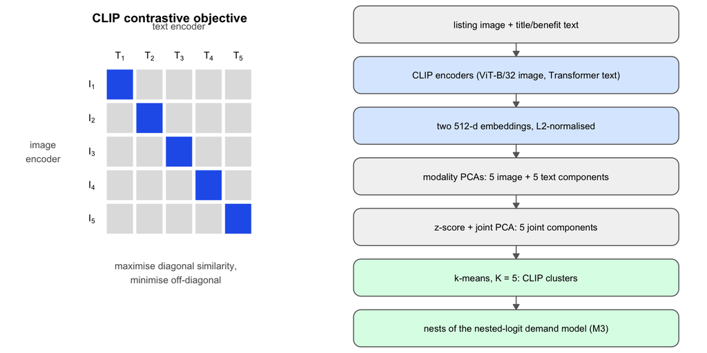

Figure 3.1: How CLIP embeddings are produced and used. Left: the contrastive training objective (after Radford et al. 2021, their Figure 1). An image encoder and a text encoder map a batch of image-caption pairs into a shared space; training pushes the correct pairings (dark diagonal cells) toward high cosine similarity and all mismatched pairings (light cells) apart. Right: the empirical pipeline of this paper, from raw listing content to the nests of model M3.

Each modality’s embeddings are first reduced to five modality-specific principal components (Hotelling 1933), with each PCA fitted only on the products holding a valid embedding for that modality. This yields a ten-dimensional characteristics vector per product, $\mathbf{x}_j = (x^{I}_{j1},\dots,x^{I}_{j5},\,x^{T}_{j1},\dots,x^{T}_{j5})$.

Because these ten columns come from two separate PCA fits, their scales are not comparable: within each modality the first component mechanically carries the largest variance, and the image and text blocks have different overall variance levels. The joint PCA is therefore computed on the correlation scale. Each column $k$ is z-scored using its mean $\mu_k$ and standard deviation $\sigma_k$ over the $N = 155$ products with both modalities,

$$z_{jk} = \frac{x_{jk} - \mu_k}{\sigma_k},$$

and the rotation matrix $\mathbf{W}$ is obtained from the PCA of the standardised matrix $\mathbf{Z}$. The first five joint components, $\mathbf{pc}_j = \mathbf{z}_j' \mathbf{W}_{[\cdot,1:5]}$, define the differentiation space used throughout the paper. Standardisation is not cosmetic: without it, the joint solution would be dominated by whichever input columns happen to carry the largest raw variance – the two first-stage PC1s – rather than by genuine cross-modality structure. The fitted parameters $(\mu_k, \sigma_k, \mathbf{W})$ are saved with the replication materials, which makes the projection of any product into the joint space exactly reproducible.

A useful diagnostic for whether the joint space actually blends the two modalities is the modality share of each component: the fraction of its squared rotation loadings attributable to image inputs,

$$\text{share}^{I}_{m} = \frac{\sum_{k \in I} w_{km}^2}{\sum_{k} w_{km}^2}, \qquad m = 1, \dots, 5.$$

As Figure 3.2 shows, every retained joint component draws between 48.6% and 51.4% of its loading mass from each modality – the joint space is genuinely multimodal rather than a relabelled image space or text space.

Finally, nests are formed by k-means clustering (Lloyd 1982) on the five joint components: each product is assigned to one of $K = 5$ clusters,

$$g_j = \arg\min_{g \in \{1,\dots,K\}} \lVert \mathbf{pc}_j - \mathbf{c}_g \rVert^2,$$

with centroids $\mathbf{c}_g$ from 50 random restarts (seed 42), and cluster membership is the nest assignment in M3. The five clusters explain 71.2% of joint-PC variance. Appendix A reports cluster-quality diagnostics – within-cluster sum of squares and average silhouette width (Rousseeuw 1987) – together with all downstream results for $K = 2, \dots, 10$.

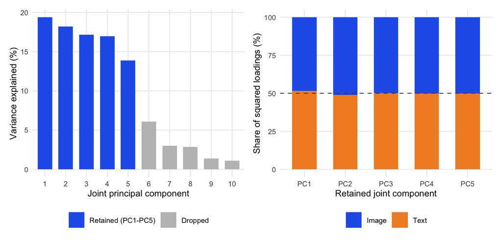

Figure 3.2: Anatomy of the joint embedding space. Left: variance explained by each joint principal component of the standardised ten-column input (five image PCs and five text PCs), fitted on the 155 ASINs with both modalities; the first five components (blue) are retained. Right: modality composition of each retained component, measured as the share of squared rotation loadings attributable to image versus text inputs. The dashed line marks an even 50/50 split; every component lies within 1.4 percentage points of it, confirming the joint space blends both modalities rather than being dominated by either.

Embeddings are static over the sample window. Established Amazon listings change their images and titles only marginally over 2018–2022, so re-extracting embeddings per quarter would produce near-identical vectors; the identifying variation is **cross-sectional** — ASINs within the same brand differ genuinely in packaging and benefit claims — and this is exactly the variation recovered by moving from brand-level to ASIN-level data. Time-varying demand conditions are absorbed by quarter fixed effects.

Twelve ASINs lack an image embedding (image retrieval failed at extraction time) but have valid text embeddings. Rather than dropping them or imputing brand means, they are projected into the joint PC space from their standardised text components, with image dimensions set to the cross-sectional mean – zero in standardised space, so that $\mathbf{pc}_j = (\mathbf{0},\, \mathbf{z}^{T}_j)'\,\mathbf{W}_{[\cdot,1:5]}$ using the same saved $(\mu_k, \sigma_k, \mathbf{W})$. These ASINs span Crest (4), Sensodyne (2), Tom’s of Maine (2), hello (2), and Other (2), and all clear the three-quarter inclusion filter. Dropping them would distort brand-level market shares and remove hello observations inside the merger simulation window; brand-mean imputation was rejected because it would reintroduce precisely the aggregation that the ASIN-level design is meant to avoid.

## 3.5 The Estimated Product Space

Table 3.2 reports summary statistics by CLIP cluster. The clusters recover economically meaningful segments without using any sales or price information: a premium sensitivity segment (C1, dominated by the GSK brands), the two mainstream incumbents in their own clusters (C2 Colgate, C3 Crest), Tom’s of Maine (C4), and a natural/specialty segment (C5) containing hello. Price levels and package sizes differ sharply across clusters, consistent with the clusters capturing vertical and horizontal differentiation simultaneously.

Table 3.2: Summary Statistics by CLIP Cluster

| Cluster | Dom. Brand | N ASINs | Price ($) Mean | Price ($) Median | Price ($) SD | Mkt. Share (x1000) Mean | Mkt. Share (x1000) Median | Mkt. Share (x1000) SD | Pkg. Size (g) Mean | Pkg. Size (g) Median | Pkg. Size (g) SD |
| --- | --- | --- | --- | --- | --- | --- | --- | --- | --- | --- | --- |
| C1 | Sensodyne | 29 | 10.26 | 9.63 | 5.58 | 1.068 | 0.770 | 0.848 | 249 | 249 | 145 |
| C2 | Colgate | 33 | 8.00 | 8.39 | 3.65 | 1.303 | 0.817 | 1.259 | 537 | 399 | 296 |
| C3 | Crest | 29 | 8.72 | 6.88 | 4.18 | 1.267 | 0.757 | 1.282 | 375 | 431 | 128 |
| C4 | Tom’s of Maine | 13 | 9.85 | 9.76 | 2.96 | 1.170 | 0.770 | 0.972 | 374 | 370 | 94 |
| C5 | Other (hello) | 55 | 9.46 | 7.86 | 6.84 | 0.839 | 0.670 | 0.736 | 171 | 141 | 105 |

Notes:  
Panel: 1,164 ASIN x quarter observations, 19 quarters (2018Q1-2022Q3). Mean/Median/SD of price in USD, market share scaled x1000, package weight in grams. Dominant brand = modal brand by ASIN count within cluster.

Beyond price and share statistics, the clusters are directly interpretable from the listing content itself. Table 3.3 reports, for each cluster, the listing-vocabulary terms that are most over-represented relative to the whole category (by lift: the share of the cluster’s ASINs whose title or benefit text contains the term, divided by the category-wide share). The vocabulary confirms that the clusters track economically meaningful positioning rather than arbitrary embedding geometry.

Table 3.3: Distinctive Listing Vocabulary by CLIP Cluster

| Cluster | Dominant brand | N ASINs | Most over-represented listing terms (by lift) |
| --- | --- | --- | --- |
| C1 | Sensodyne | 29 | sensodyne, parodontax, extra, bleeding, pronamel, reharden |
| C2 | Colgate | 33 | optic, hydrogen, max, benefits, extreme, frosty |
| C3 | Crest | 29 | scope, pro, radiant, brilliance, eraser, glamorous |
| C4 | Tom’s of Maine | 13 | maine, tom’s, children’s, silly, animals, not |
| C5 | Other | 55 | sls, activated, mouth, orajel, remineralizing, anti |

Notes:  
Terms from ASIN titles and benefit descriptions (lower-cased, unit and category stopwords removed). Lift = share of the cluster’s ASINs containing the term divided by the category-wide share; terms shown appear in at least two of the cluster’s ASINs and have lift above 1.5, ranked by lift. Cluster assignment identical to the estimation (K = 5, seed 42).

Figure 3.3 visualises the CLIP product space: hello’s listings sit in the natural/specialty cluster on the left of the embedding plane while Colgate’s cluster occupies the opposite region, making the low implied diversion between the merging parties directly visible.

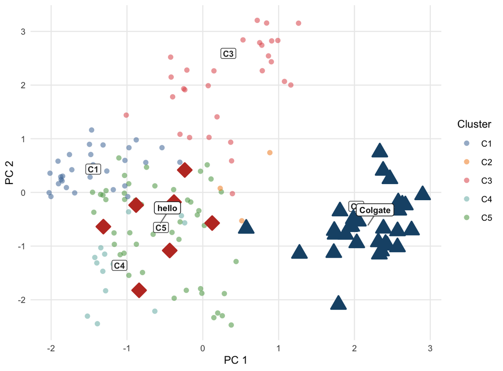

Figure 3.3: Product space from CLIP embeddings. Each point is one ASIN positioned by its first two principal components of the joint image+text embedding. Cluster centroids are labelled C1–C5. hello (red diamonds, C5) and Colgate (dark blue triangles, C2) occupy different clusters, implying a lower diversion ratio and a smaller predicted merger effect under CLIP nesting relative to plain logit.

# 4 Empirical Framework

## 4.1 Berry (1994) Linearisation

All three models are estimated via the Berry (1994) nested-logit linearisation:

$$\log\frac{s_{jt}}{s_{0t}} - \rho\,\log s_{j|g,t} = \alpha\,p_{jt} + \boldsymbol{\beta}'\mathbf{x}_{jt} + \text{FE}_t + \xi_{jt}$$

where $s_{j|g,t} = s_{jt}/\!\sum_{k\in g}s_{kt}$ is the within-nest share, $\rho\in[0,1)$ is the nesting intensity, and $\text{FE}_t$ are quarter fixed effects (absorbed by within-quarter demeaning). The underlying choice model is the generalised-extreme-value family of McFadden (1974, 1978), of which the nested logit is the leading closed-form member; the error-components representation that motivates $\rho$ is due to Cardell (1997), and Train (2009, chs. 3–4) gives a textbook treatment.

This estimating equation is not assumed but follows from the nested-logit choice probabilities, and it is worth tracing the one step that carries the paper’s contribution. Consumer $i$’s utility from product $j$ in nest $g$ is $u_{ijt} = \delta_{jt} + \zeta_{igt} + (1-\rho)\,\varepsilon_{ijt}$, where $\delta_{jt} = \alpha\,p_{jt} + \boldsymbol{\beta}'\mathbf{x}_{jt} + \text{FE}_t + \xi_{jt}$ is the mean utility, $\varepsilon_{ijt}$ is i.i.d. extreme-value, and $\zeta_{igt}$ is the nest-specific error component of Cardell (1997) that generates within-nest correlation of strength $\rho$. Writing $D_{gt} = \sum_{k\in g}\exp\!\big(\delta_{kt}/(1-\rho)\big)$ for the nest’s inclusive value, the GEV probabilities factor into a within-nest and a between-nest term,
$$s_{jt} = s_{j|g,t}\cdot s_{g,t},\qquad s_{j|g,t} = \frac{\exp\!\big(\delta_{jt}/(1-\rho)\big)}{D_{gt}},\qquad s_{g,t} = \frac{D_{gt}^{\,1-\rho}}{\sum_{g'} D_{g't}^{\,1-\rho}}.$$
Normalising the outside good as a singleton nest with $\delta_{0t}=0$ gives $s_{g,t}/s_{0t} = D_{gt}^{\,1-\rho}$, so that $\log s_{jt} - \log s_{0t} = \log s_{j|g,t} + (1-\rho)\log D_{gt}$. The within-nest expression rearranges to $\log D_{gt} = \delta_{jt}/(1-\rho) - \log s_{j|g,t}$; substituting it in and cancelling yields the Berry (1994) linearisation directly:
$$\log\frac{s_{jt}}{s_{0t}} = \delta_{jt} + \rho\,\log s_{j|g,t}.$$
The nesting parameter $\rho$ therefore enters the regression through a single observable term, $\log s_{j|g,t}$, and the nest $g$ enters *only* through the composition of that within-nest share. The specification is thus agnostic about what defines a nest: any partition of products into groups produces a valid $s_{j|g,t}$. This is precisely the degree of freedom the paper exploits – Section 3.4 defines $g$ from CLIP embedding clusters rather than from brand identity, leaving every other element of the equation unchanged.

## 4.2 Price Coefficient Calibration

$$\alpha = \frac{\varepsilon_{\text{target}}}{\operatorname{median}(p_{jt}(1-s_{jt}))} = \frac{-2.62}{8.4502} = -0.310$$

The target $\varepsilon_{\text{target}} = -2.62$ corresponds to the brand-level CPG meta-analysis mean of Bijmolt, van Heerde & Pieters (2005, p. 141), consistent with structural BLP estimates for analogous packaged-goods categories (Nevo 2001; Draganska & Jain 2006).

**Sequential calibration note.** Since $\alpha$ is calibrated at $\rho=0$, the target elasticity $-2.62$ is the plain-logit median. At the profiled nesting parameters, the nested-logit elasticity formula amplifies own-price sensitivity by roughly $1/(1-\rho^{*})$, so the same $\alpha$ implies median own-price elasticities of $-3.83$ under M2 and $-7.31$ under M3 (computed observation by observation; the $1/(1-\rho^{*})$ back-of-envelope gives $-4.0$ and $-7.9$). These larger magnitudes are not in tension with the calibration target. The Bijmolt, van Heerde, and Pieters (2005) mean is dominated by brand- and aggregate-level estimates, whereas the products here are individual ASINs, which face much closer substitutes than a brand aggregate does – finer product definitions mechanically imply more elastic demand. Structural estimates at the product-line level are correspondingly larger: Draganska and Jain (2006) report own-price elasticities between $-2.45$ and $-6.25$, and the implied medians here sit at the top of and beyond that range ($-3.83$ under M2, $-7.31$ under M3) – exactly the pattern the finer ASIN-level product definition predicts, since individual listings face closer substitutes than the product lines in their data. Appendix C reports a robustness exercise that rescales $\alpha$ within each nested model so that the model’s own implied median equals $-2.62$ at its profiled $\rho^{*}$: doing so shrinks $|\alpha|$, inflates Bertrand markups, and drives the negative-cost rate far above even the plain-logit level. In other words, ASIN-level demand must be substantially more elastic than the aggregate benchmark for observed prices to be rationalizable at all – the cost side independently validates the more elastic implied elasticities.

## 4.3 $\rho^*$ Selection — Concentrated OLS Profile

For each $\rho$ on a fine grid $\{0, 0.01, \ldots, 0.90\}$, the adjusted dependent variable is formed and $\boldsymbol{\beta}(\rho)$ is estimated by OLS. The profiled $\rho^*$ minimises the residual sum of squares:

$$\tilde{y}_{jt}(\rho) = \log\frac{s_{jt}}{s_{0t}} - \alpha p_{jt} - \rho\log s_{j|g,t}, \qquad \rho^* = \arg\min_\rho \left\|\tilde{y}(\rho) - \mathbf{X}\hat{\boldsymbol{\beta}}(\rho)\right\|^2$$

## 4.4 Marginal Costs and Merger Simulation

Marginal costs are recovered from the pre-merger Bertrand first-order condition (Berry 1994):

$$\mathbf{mc} = \mathbf{p} + (\Omega_{\text{pre}} \circ \Delta)^{-1}\mathbf{s}$$

where $\Omega[j,k] = \mathbf{1}[\text{firm}_j = \text{firm}_k]$ and $\Delta$ is the demand Jacobian with elements:

$$\Delta_{jj} = \alpha s_j\!\left[\tfrac{1}{1-\rho} - \tfrac{\rho}{1-\rho}s_{j|g} - s_j\right], \quad \Delta_{jk}^{\text{same}} = \alpha s_j\!\left[-\tfrac{\rho}{1-\rho}s_{k|g} - s_k\right], \quad \Delta_{jk}^{\text{diff}} = -\alpha s_j s_k$$

**Remark (brand nests and ownership).** Marginal-cost recovery interacts with the nest assignment in one important, exact way. When every nest lies wholly inside one firm – as with brand nests, where each firm owns complete brands – the nested-logit Bertrand first-order conditions admit the same solution as plain logit: markups are uniform within each firm at $1/(|\alpha|(1-S_f))$, where $S_f$ is the firm’s inside share, for *any* value of $\rho$ (proof in Appendix D). Consequently, M1 and M2 recover *identical* marginal costs at every observation, identical Lerner indices, and identical negative-cost rates. Brand nesting is therefore incapable of repairing the cost side of the model in this market by construction; only a nest assignment that cuts across ownership boundaries – such as the CLIP clusters, which group ASINs of different firms – can change recovered costs. The counterfactual equilibria of M1 and M2 still differ slightly, because the share *functions* $s(p)$ differ even though markups at observed shares coincide.

Marginal costs are averaged per ASIN across pre-merger quarters and held fixed in both counterfactuals. Holding costs at pre-merger values serves two purposes: it embodies the standard no-efficiencies assumption of prospective merger review (Farrell and Shapiro 1990), and it avoids a mechanical tautology – if costs were re-inverted in post-merger quarters, the no-merger Nash equilibrium would recover observed prices by construction, since the first-order condition is the identity that defined those costs.

Two Nash equilibria are then computed for every post-merger quarter via a damped fixed-point iteration on the Bertrand first-order conditions (Morrow and Skerlos 2011):

$$\mathbf{p}_{n+1} = \lambda\left[\mathbf{mc} - (\Omega \circ \Delta(\mathbf{p}_n))^{-1}\mathbf{s}(\mathbf{p}_n)\right] + (1-\lambda)\,\mathbf{p}_n$$

with $\lambda = 0.4$, convergence tolerance $10^{-8}$, and up to 2,000 iterations. The no-merger counterfactual uses pre-merger ownership $\Omega_{\text{pre}}$; the merger simulation replaces it with $\Omega_{\text{post}}$ (hello ASINs assigned to Colgate’s firm identifier from 2020Q1). The merger price effect is the difference between the two equilibria, $\Delta p = p^{\text{merger}} - p^{\text{no-merger}}$, so that ownership structure is the only thing that varies between them.

**Algorithm validation.** The R implementation mirrors the counterfactual equilibrium routines in PyBLP (Conlon & Gortmaker 2020) and is validated against PyBLP’s `compute_prices()` directly: for both M1 (plain logit) and M3 (CLIP-nested, $\rho^*=0.67$), the maximum absolute price difference across 847 post-merger observations is below $2 \times 10^{-8}$, confirming algorithmic equivalence.

# 5 Results

## 5.1 Demand Estimates

Table 5.1 presents the demand parameters for all three models, separating the calibrated $\alpha$ from the estimated $\boldsymbol{\beta}$ and the profiled $\rho^{*}$. Brand nesting yields $\rho^{*}=0.35$ with a 3.1% RSS improvement over plain logit; CLIP nesting yields $\rho^{*}=0.67$ with an 8.1% improvement. The stronger profiled nesting parameter indicates that within-cluster substitution is substantially more intense when clusters are defined in embedding space than when they are defined by brand identity.

Table 5.1: Demand Parameter Estimates — Three Models

| Variable | M1: Logit (rho=0) | M2: Brand-Nested (rho*=0.35) | M3: CLIP-Nested (rho*=0.67) |
| --- | --- | --- | --- |
| alpha (price) | -0.310 + | -0.310 + | -0.310 + |
| Package size (g) | 0.0037*** (0.0003) | 0.0037*** (0.0003) | 0.0034*** (0.0003) |
| CLIP PC1 | -0.4034*** (0.0424) | -0.2869*** (0.0418) | -0.3280*** (0.0407) |
| CLIP PC2 | 0.2033*** (0.0374) | 0.2681*** (0.0368) | 0.2103*** (0.0359) |
| CLIP PC3 | -0.1667*** (0.0386) | -0.1479*** (0.0380) | -0.2854*** (0.0370) |
| CLIP PC4 | 0.2115*** (0.0399) | 0.1574*** (0.0393) | 0.2707*** (0.0382) |
| CLIP PC5 | -0.1652*** (0.0390) | -0.1243*** (0.0384) | -0.1745*** (0.0374) |
| Other brand | 0.0849 (0.1327) | 0.4590*** (0.1307) | 0.2641** (0.1272) |
| Import x freight shock | 0.6767*** (0.2342) | 0.6709*** (0.2306) | 0.7461*** (0.2245) |
| rho* | 0.000 ++ | 0.350 ++ | 0.670 ++ |
| Quarter FEs | Yes | Yes | Yes |
| Median implied elasticity | -2.62 | -3.83 | -7.31 |
| RSS drop vs rho=0 | – | 3.1% | 8.1% |

Notes:  
Standard errors in parentheses. Significance: **p<0.01,** p<0.05, p<0.10. Quarter FEs absorbed by demeaning. 1,164 obs., 159 ASINs, 19 quarters. + Calibrated: alpha = eps_target / median(p(1-s)) = -2.62/8.45. Not estimated. ++ Grid-searched on {0, 0.01, …, 0.90}; rho=0 fixed for M1.

## 5.2 Own-Price Elasticities by Brand

Table 5.2 reports median own-price elasticities by brand group for each model. Two patterns are worth noting. First, within each model, elasticities scale with price levels – the nested-logit own-price elasticity is proportional to $\alpha p_j$, so premium brands such as APAGARD and SENSODYNE PRONAMEL are mechanically the most elastic. Second, and more informative, moving from M1 to M3 amplifies all elasticities by roughly $1/(1-\rho^{*})$, but the amplification interacts with cluster composition: brands sharing a crowded embedding cluster face the strongest within-nest competition. The merging parties illustrate the point – hello’s median elasticity rises from $-1.42$ under plain logit to $-4.05$ under CLIP nesting, reflecting the intense substitution among the natural/specialty products in its cluster rather than substitution toward Colgate.

Table 5.2: Median Own-Price Elasticities by Brand Group

| Brand | N obs. | M1: Logit | M2: Brand-Nested | M3: CLIP-Nested |
| --- | --- | --- | --- | --- |
| APAGARD | 44 | -4.92 | -6.62 | -14.33 |
| Sensodyne | 99 | -3.00 | -4.27 | -8.68 |
| SENSODYNE PRONAMEL | 90 | -3.04 | -4.42 | -8.67 |
| Colgate | 224 | -2.84 | -4.27 | -8.24 |
| Tom’s of Maine | 85 | -3.03 | -4.38 | -8.07 |
| Other | 220 | -2.70 | -4.09 | -7.98 |
| Crest | 219 | -2.11 | -3.18 | -6.17 |
| Parodontax | 51 | -1.79 | -2.54 | -5.29 |
| Arm & Hammer | 21 | -1.53 | -1.62 | -4.22 |
| hello | 50 | -1.42 | -1.88 | -4.05 |
| JASON | 29 | -1.30 | -1.48 | -3.77 |
| Orajel | 32 | -0.86 | -1.16 | -2.53 |

Notes:  
Median own-price elasticity across all ASIN x quarter observations of each brand group, full estimation panel (1,164 observations). Elasticities use the nested-logit formula of Section 4.4 with the calibrated alpha (-0.310) and each model’s profiled rho (0 for M1, 0.35 for M2, 0.67 for M3). Rows sorted by M3 elasticity; bold = merger parties.

## 5.3 Diversion Ratios

The merger question turns on where hello’s demand goes when its prices rise. Table 5.3 reports diversion ratios $DR_{j \to k} = -(\partial s_k / \partial p_j) / (\partial s_j / \partial p_j)$ from hello ASINs, aggregated into fixed reporting buckets (share-weighted across hello products and pre-merger quarters). Diversion ratios are the central input of modern unilateral-effects screening (Farrell and Shapiro 2010; Conlon and Mortimer 2021), and they enter the U.S. Horizontal Merger Guidelines directly through the pricing-pressure analysis of differentiated products (U.S. Department of Justice and Federal Trade Commission 2010, sec. 6.1).

Table 5.3: Diversion from hello by Destination (percent of lost demand)

| Model | To Colgate | To rest of hello’s CLIP cluster | To other inside goods | To outside good |
| --- | --- | --- | --- | --- |
| M1: Logit | 1.16 | 1.49 | 3.88 | 93.47 |
| M2: Brand-Nested | 0.93 | 1.20 | 22.41 | 75.45 |
| M3: CLIP-Nested | 0.41 | 58.14 | 8.39 | 33.06 |

Notes:  
Share-weighted average across hello ASINs and pre-merger quarters (2018Q1–2019Q4), computed from each model’s demand Jacobian at observed shares with the calibrated alpha and the model’s profiled rho*. Reporting buckets are fixed across models: Colgate-brand products, remaining products in hello’s CLIP cluster (C5), all other inside goods, and the outside good. Rows may not sum to 100 due to rounding.

The three demand systems tell three different stories about the same market. Under plain logit, diversion is proportional to market shares, so 93% of hello’s marginal demand flows to the outside good and only 1.2% reaches Colgate. Brand nesting redirects substitution toward hello’s own sister ASINs but leaves cross-brand diversion share-proportional. Under CLIP nesting, 58% of hello’s lost demand diverts to the other natural/specialty products in its cluster, while diversion to Colgate falls to 0.4% – the low-diversion configuration that drives the small simulated merger effect in the next subsection.

## 5.4 Merger Counterfactuals

Table 5.4 reports the merger counterfactuals: observed prices, recovered marginal costs, the no-merger Nash equilibrium, the merger Nash equilibrium, and the implied price effect $\Delta p$ for the merging parties and the largest rivals. Under plain logit, where diversion is proportional to market shares, the simulated effect for hello is +1.23%; brand nesting barely changes it (+1.28%) because hello’s ASINs sit in their own brand nest and diversion to Colgate is still share-proportional across nests. Under CLIP nesting, hello (cluster C5) and Colgate (cluster C2) are distant in product space, diversion between the parties is small, and the simulated hello effect falls to +0.40%, with Colgate’s own effect economically negligible.

Table 5.4: Merger Counterfactuals: hello-to-Colgate Acquisition (2020Q1)

| Brand | Obs. p | MC | Nash (pre) | Nash (post) | p | p % |
| --- | --- | --- | --- | --- | --- | --- |
| **M1: Logit (rho=0)** |  |  |  |  |  |  |
| hello | 6.43 | 3.20 | 7.10 | 7.16 | 0.064 | 1.233% |
| Colgate | 8.45 | 5.16 | 8.29 | 8.30 | 0.007 | 0.104% |
| Tom’s of Maine | 10.47 | 7.17 | 10.70 | 10.71 | 0.006 | 0.069% |
| Crest | 8.87 | 5.60 | 9.18 | 9.18 | 0.000 | 0.000% |
| Sensodyne | 10.45 | 7.17 | 10.05 | 10.05 | 0.000 | 0.000% |
| **M2: Brand-Nested (rho*=0.35)** |  |  |  |  |  |  |
| hello | 6.43 | 3.20 | 7.10 | 7.17 | 0.065 | 1.275% |
| Colgate | 8.45 | 5.16 | 8.30 | 8.30 | 0.006 | 0.104% |
| Tom’s of Maine | 10.47 | 7.17 | 10.71 | 10.71 | 0.006 | 0.069% |
| Crest | 8.87 | 5.60 | 9.18 | 9.18 | 0.000 | 0.000% |
| Sensodyne | 10.45 | 7.17 | 10.07 | 10.07 | 0.000 | 0.000% |
| **M3: CLIP-Nested (rho*=0.67)** |  |  |  |  |  |  |
| hello | 6.43 | 5.20 | 7.05 | 7.07 | 0.020 | 0.404% |
| Colgate | 8.45 | 5.88 | 8.59 | 8.59 | 0.002 | 0.018% |
| Tom’s of Maine | 10.47 | 7.19 | 10.72 | 10.72 | 0.002 | 0.021% |
| Crest | 8.87 | 5.63 | 9.18 | 9.18 | 0.000 | 0.000% |
| Sensodyne | 10.45 | 7.28 | 10.29 | 10.29 | 0.000 | 0.000% |

Notes:  
All prices USD; post-merger averages (2020Q1–2022Q3). Bold = merger parties. Nash (pre): Bertrand-Nash under pre-merger ownership. Nash (post): equilibrium under merged ownership. Dp = Nash (post) minus Nash (pre). MC inverted from pre-merger FOC and held fixed.

Figure 5.1 traces the post-merger window quarter by quarter, showing the merger Nash equilibrium diverging from the no-merger counterfactual for hello while the two paths for Colgate remain indistinguishable.

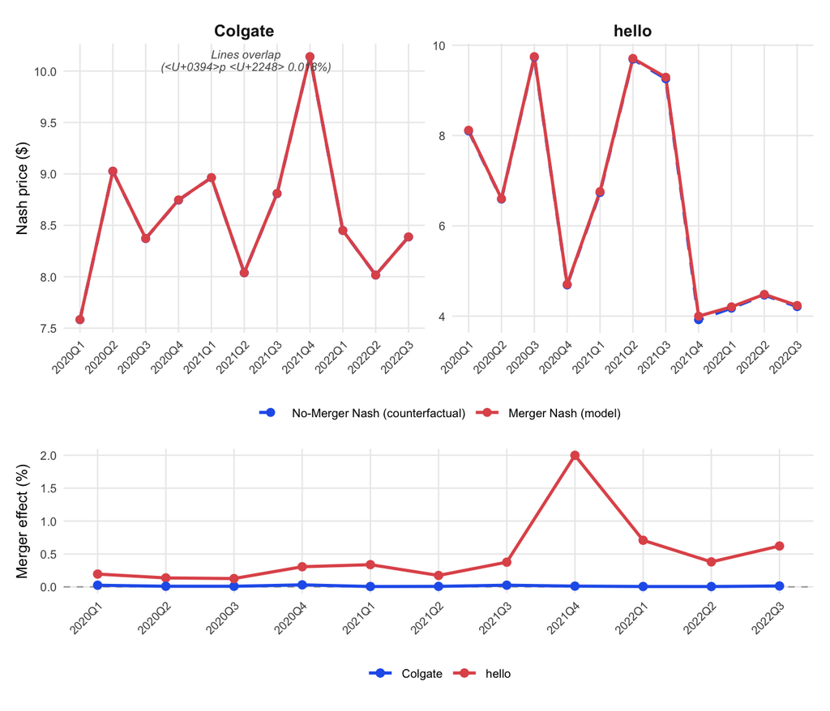

Figure 5.1: Merger simulation price trajectories (Model 3, CLIP-Nested, $\rho^*=0.67$). Top panel: Nash equilibrium prices under merged and pre-merger ownership. Observed prices are omitted from the top panel because their quarter-to-quarter variation ($4–$10) would compress the counterfactual divergence. Bottom panel: merger price effect in percent, $(p^{\text{merger}} - p^{\text{no-merger}})/p^{\text{no-merger}} \times 100$. hello (red) shows a positive and time-varying effect; Colgate (blue) remains near zero.

## 5.5 Cross-Model Comparison

The central economic-plausibility comparison across the three models is summarised below. The share of observations with **negative implied marginal costs** is the key diagnostic: when the demand system understates substitutability, the Bertrand inversion attributes implausibly large markups, pushing recovered costs below zero. CLIP-based nesting reduces the negative-MC rate from 8.6% to 1.7% — a five-fold improvement — while simultaneously delivering the largest RSS improvement. That M1 and M2 display *exactly* the same negative-cost rate, cost levels, and Lerner indices is not a coincidence: because brand nests coincide with ownership boundaries, brand-nested Bertrand markups are identical to plain-logit markups for any $\rho$ (Section 4.4 and Appendix D). The cost side of the model can only improve when nests cut across firms, which is precisely what CLIP clustering delivers. The final column translates the price effects into consumer terms via the nested-logit inclusive-value formula (Small and Rosen 1981); implied consumer harm under CLIP nesting is roughly a third of the logit-implied harm.

Table 5.5: Cross-Model Comparison: Demand Fit and Economic Plausibility

| Model | rho* | Med. elasticity | RSS drop | Neg. MC % | Med. Lerner | hello Dp | Colgate Dp | dCS |
| --- | --- | --- | --- | --- | --- | --- | --- | --- |
| M1: Logit | 0.00 | -2.62 | — | 8.6% | 38.5% | +1.23% | +0.104% | -25.4 |
| M2: Brand-Nested | 0.35 | -3.83 | 3.1% | 8.6% | 38.5% | +1.27% | +0.104% | -26.6 |
| M3: CLIP-Nested | 0.67 | -7.31 | 8.1% | 1.7% | 28.9% | +0.40% | +0.018% | -8.5 |

Notes:  
All statistics over the full estimation panel (1,164 ASIN x quarter observations) except merger effects (post-merger quarters 2020Q1–2022Q3). Med. elasticity = median own-price elasticity. RSS drop = reduction in residual sum of squares vs rho=0 from the concentrated OLS profile. Neg. MC = share of observations with negative implied marginal cost from the Bertrand inversion (lower = more economically plausible). Med. Lerner = median (p - mc)/p. hello / Colgate Dp = average post-merger Nash price effect. dCS = mean change in consumer surplus, merger vs no-merger Nash, in cents per 1,000 consumers per quarter (nested-logit log-sum formula). Bold/green row = preferred specification.

## 5.6 Placebo Nesting Tests

The negative-MC result invites a sharp question: is the improvement specific to the *semantic content* of the CLIP embeddings, or would any five-way partition that cuts across ownership boundaries do as well? Appendix D shows the cost side can improve only when nests cross firms, so the concern is real. We test it head-on. Two placebo nestings are drawn 200 times each and pushed through the identical pipeline – calibration, $\rho$ profile, cost inversion, and merger simulation: (A) each ASIN assigned to one of five nests uniformly at random, and (B) the CLIP cluster labels permuted across ASINs, which holds the CLIP nest-size distribution fixed while severing the product-to-embedding link. The harness reproduces the real CLIP figures exactly (hello effect +0.404%), so the placebos are measured on the same ruler.

Table 5.6 and Figure 5.2 separate what is generic from what is specific to CLIP.

*The cost-side repair is generic.* Random cross-firm nests lower the negative-MC rate to a median of 0.9%, matching CLIP’s 1.7% or bettering it in 96% of draws. Any partition that crosses ownership repairs the cost side, exactly as Appendix D predicts. The 8.6% to 1.7% drop is a genuine and important property of CLIP nesting, but on its own it does not isolate the embeddings.

*The demand fit is not generic.* CLIP’s RSS drop of 8.1% exceeds that of 95% of random partitions (median 5.3%), and its $\rho^{*}=0.67$ exceeds 95.5% of them. A nesting lowers residual variance only when the products grouped together genuinely share demand shocks; CLIP achieves this because embedding-similar products are economically similar, whereas random groupings add mostly noise.

*The merger prediction is not generic – and this is decisive.* CLIP’s hello price effect of +0.40% lies below *every one* of the 200 random draws, which range from +2.5% at the minimum to +10.2% at the maximum (median +5.9%, a fourteen-fold gap; Table 5.6 reports the narrower 5–95% band). The mechanism is economic, not statistical. Colgate sells many ASINs; a random partition scatters them across all five nests, so hello’s nest almost always contains some Colgate products by accident, manufacturing hello-to-Colgate diversion that has no economic basis and inflating the simulated effect. CLIP places Colgate’s entire product line in a single cluster, cleanly apart from hello’s natural/specialty cluster, so the diversion between the merging parties – and hence the merger effect – reflects genuine product differentiation rather than an artifact of random co-nesting. Placebo B sharpens this: permuting the CLIP labels holds the nest-size distribution exactly fixed, yet still lowers the negative-MC rate (median 1.6%) while inflating the hello effect (median +5.2%). It is therefore the *assignment* of products to nests, not the sizes of the nests, that CLIP gets right.

*Nor is a hand-coded classification a substitute.* One further question a referee would ask: could a human analyst reading the listings simply build these nests by hand? We construct a keyword classifier on the raw title and benefit text (kids, sensitivity, whitening, natural, standard), in two tie-breaking orders since most listings carry several benefit claims, and run both through the same pipeline. The keyword nests fit demand worse than the *median random partition* (RSS drops of 4.2% and 4.4% against the random median of 5.3%), and both variants predict hello price effects above +4.5%. The natural-first variant fails in an instructive way: it does separate hello from the Colgate brand, but it pulls thirteen Tom’s of Maine listings – Colgate-owned – into hello’s nest, because Tom’s carries the same natural keywords. CLIP instead assigns hello, Colgate, and Tom’s of Maine to three *different* clusters: the embeddings register that hello’s bright, design-led positioning is not Tom’s of Maine’s earth-toned health-store positioning, a distinction invisible to any keyword list, and the demand data reward exactly this distinction with the largest fit improvement.

The three results together give the precise statement of the contribution. Cross-firm nesting of any kind can repair the cost side; only CLIP repairs it *while* fitting demand better than 95% of random partitions and delivering a merger counterfactual free of the spurious diversion those partitions introduce. Brand nesting, at the other extreme, separates the merging parties but leaves the cost side untouched (Appendix D). A keyword classification fares no better: it fits worse than the median random draw and, in its natural-first form, co-nests hello with Colgate’s natural subsidiary. Of the nesting rules considered, CLIP is the only one that satisfies all three criteria at once.

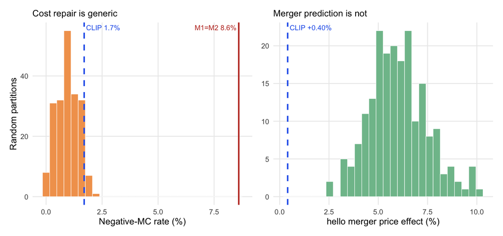

Figure 5.2: Placebo nesting tests (200 random cross-firm partitions). Left: the negative-MC rate under random nests (bars) reaches CLIP’s level (blue dashed) or lower in 96% of draws – the cost-side repair is generic, far below the M1=M2 baseline (red). Right: the simulated hello merger price effect under random nests ranges from +2.5% to +10.2%; CLIP’s +0.40% (blue dashed) lies below all 200 draws, because CLIP alone keeps Colgate’s product line out of hello’s nest.

Table 5.6: Placebo and Baseline Nesting Tests: CLIP vs Random, Shuffled, and Hand-Coded Partitions

| Metric | CLIP (real) | Random A (median [5-95%]) | Shuffled B (median) | Keywords (nat.-first) |
| --- | --- | --- | --- | --- |
| rho* | 0.67 | 0.53 [0.39, 0.66] | 0.41 | 0.44 |
| RSS drop (%) | 8.10 | 5.30 [3.00, 7.91] | 4.00 | 4.40 |
| Neg-MC (%) | 1.70 | 0.90 [0.20, 1.70] | 1.60 | 1.90 |
| hello effect (%) | 0.40 | 5.87 [3.80, 8.73] | 5.15 | 5.52 |
| Colgate effect (%) | 0.02 | 0.41 [0.26, 0.59] | 0.39 | 0.08 |

Notes:  
200 draws each. Random A: every ASIN assigned to one of five nests uniformly at random (cross-firm, no semantics). Shuffled B: CLIP cluster labels permuted across ASINs (CLIP nest-size distribution preserved). All draws run through the identical calibration, rho profile, cost inversion, and merger simulation as M3. Keywords = hand-coded keyword categories from the raw listing text, natural-first tie-breaking (the benefit-first variant is similar: RSS drop 4.2%, hello +4.51%). hello effect = average post-merger Nash price effect for hello. Bold row = the decisive result: CLIP’s +0.40% lies below all 200 random draws (min +2.5%).

# 6 Discussion and Limitations

The findings should be read with the design’s limitations in view; each is a deliberate trade-off rather than an oversight, and each points to a concrete extension.

**Calibrated price coefficient.** Valid cost-side instruments are unavailable in this high-frequency online retail panel, so $\alpha$ is calibrated to an external meta-analytic elasticity rather than estimated. The choice makes the price-sensitivity assumption transparent, but it also means $\alpha$ is common across products and the level of all markups inherits the calibration. Because $\alpha$ is calibrated at $\rho = 0$, the nested models imply more elastic demand at their profiled $\rho^{*}$; the cross-model *comparison* of fit, negative-cost rates, and merger effects is unaffected, since all three models share the same $\alpha$. A natural extension is to construct differentiation instruments (Gandhi and Houde 2019) from the CLIP embeddings themselves – rival products’ embedding distances are plausibly excluded from a product’s own demand shock – and estimate $\alpha$ rather than calibrate it.

**Demand-side cost recovery.** Marginal costs are recovered solely from the demand system and the Bertrand first-order conditions; without a supply-side cost equation, true cost variation cannot be separated from demand shocks absorbed into the inversion. The negative-cost rate is used here precisely as a *diagnostic* of demand misspecification, which is robust to this concern, but the recovered cost levels should not be interpreted structurally.

**Fixed marginal costs and no efficiencies.** The counterfactuals hold costs at pre-merger levels, isolating the market-power effect of the ownership change. If the acquisition generated real marginal-cost efficiencies, the simulated price effects are upper bounds for the merged firm’s products.

**External validity.** The analysis covers one category on one platform around one merger. The pipeline, however, requires only listing content, purchase counts, and prices – data available for essentially any e-commerce category – which is what makes the approach portable to other merger settings.

# 7 Conclusion

This paper provides evidence that substitution patterns constructed from unstructured product content outperform those built from brand labels in a workhorse merger-simulation framework. Replacing brand nests with CLIP-embedding clusters in a Berry (1994) nested logit raises demand fit, cuts the rate of economically implausible negative implied marginal costs from 8.6% to 1.7%, and changes the antitrust answer: the simulated price effect of the hello–Colgate acquisition for hello falls from +1.23% under plain logit to +0.40% under CLIP nesting, because the embeddings reveal that the merging parties occupy different regions of product space and divert little demand to one another.

The broader message for practice is that the inputs to credible merger simulation need not be limited to structured characteristics data. Product images and listing text – observable for any online market at essentially zero cost – carry the differentiation consumers act on, and a pre-trained encoder plus standard clustering suffices to put that information into the tools antitrust economists already use. The entire analysis, from embeddings to Nash counterfactuals, is reproducible from a single document and a public repository, which is intended to make the method auditable in exactly the settings where it would be applied.

# Data and Code Availability

All data, code, and the R Markdown source of this paper are openly available at https://github.com/brkuzn/clip-amazon-toothpaste-market. Knitting the source document re-runs the entire pipeline – the joint PCA, the $\rho$ grid searches, and the Bertrand–Nash equilibria – and regenerates every table and figure from the included data. The repository also contains the CLIP extraction notebook, the joint-PCA construction script, and reference copies of all outputs; reproduction of the shipped joint principal components is byte-exact. Raw household-level purchase records with demographics are not redistributed and are available from the Open E-commerce 1.0 repository (Berke et al. 2024).

# References

Bajari, P., Nekipelov, D., Ryan, S.P., & Yang, M. (2015). Machine learning methods for demand estimation. *American Economic Review*, 105(5), 481–485.

Berke, A., Calacci, D., Mahari, R., Yabe, T., Larson, K., & Pentland, S. (2024). Open e-commerce 1.0, five years of crowdsourced U.S. Amazon purchase histories with user demographics. *Scientific Data*, 11, 491. https://doi.org/10.1038/s41597-024-03329-6

Berry, S.T. (1994). Estimating discrete-choice models of product differentiation. *RAND Journal of Economics*, 25(2), 242–262.

Berry, S.T., Levinsohn, J., & Pakes, A. (1995). Automobile prices in market equilibrium. *Econometrica*, 63(4), 841–890.

Bijmolt, T.H.A., van Heerde, H.J., & Pieters, R.G.M. (2005). New empirical generalizations on the determinants of price elasticity. *Journal of Marketing Research*, 42(2), 141–156.

Björnerstedt, J., & Verboven, F. (2016). Does merger simulation work? Evidence from the Swedish analgesics market. *American Economic Journal: Applied Economics*, 8(3), 125–164.

Cardell, N.S. (1997). Variance components structures for the extreme-value and logistic distributions with application to models of heterogeneity. *Econometric Theory*, 13(2), 185–213.

Compiani, G., Morozov, I., & Seiler, S. (2026). Demand estimation with text and image data. *The RAND Journal of Economics*. https://doi.org/10.1111/1756-2171.70052

Conlon, C., & Gortmaker, J. (2020). Best practices for differentiated products demand estimation with PyBLP. *RAND Journal of Economics*, 51(4), 1108–1161.

Conlon, C., & Mortimer, J.H. (2021). Empirical properties of diversion ratios. *RAND Journal of Economics*, 52(4), 693–726.

Dosovitskiy, A., Beyer, L., Kolesnikov, A., Weissenborn, D., Zhai, X., Unterthiner, T., & Houlsby, N. (2021). An image is worth 16x16 words: Transformers for image recognition at scale. *International Conference on Learning Representations (ICLR)*.

Draganska, M., & Jain, D.C. (2006). Consumer preferences and product-line pricing strategies: An empirical analysis. *Marketing Science*, 25(2), 164–174.

Farrell, J., & Shapiro, C. (1990). Horizontal mergers: An equilibrium analysis. *American Economic Review*, 80(1), 107–126.

Farrell, J., & Shapiro, C. (2010). Antitrust evaluation of horizontal mergers: An economic alternative to market definition. *The B.E. Journal of Theoretical Economics*, 10(1), Article 9.

Gandhi, A., & Houde, J.-F. (2019). Measuring substitution patterns in differentiated-products industries. NBER Working Paper 26375.

Grigolon, L., & Verboven, F. (2014). Nested logit or random coefficients logit? A comparison of alternative discrete choice models of product differentiation. *Review of Economics and Statistics*, 96(5), 916–935.

Hausman, J.A. (1996). Valuation of new goods under perfect and imperfect competition. In T.F. Bresnahan & R.J. Gordon (Eds.), *The Economics of New Goods* (pp. 209–237). University of Chicago Press.

Hotelling, H. (1933). Analysis of a complex of statistical variables into principal components. *Journal of Educational Psychology*, 24(6), 417–441.

Lloyd, S.P. (1982). Least squares quantization in PCM. *IEEE Transactions on Information Theory*, 28(2), 129–137.

Magnolfi, L., McClure, J., & Sorensen, A.T. (2025). Triplet embeddings for demand estimation. *American Economic Journal: Microeconomics*, 17(1), 282–307.

McFadden, D. (1974). Conditional logit analysis of qualitative choice behavior. In P. Zarembka (Ed.), *Frontiers in Econometrics* (pp. 105–142). Academic Press.

McFadden, D. (1978). Modelling the choice of residential location. In A. Karlqvist, L. Lundqvist, F. Snickars, & J.W. Weibull (Eds.), *Spatial Interaction Theory and Planning Models* (pp. 75–96). North-Holland.

Morrow, W.R., & Skerlos, S.J. (2011). Fixed-point approaches to computing Bertrand-Nash equilibrium prices under mixed-logit demand. *Operations Research*, 59(2), 328–345.

Nevo, A. (2000a). A practitioner’s guide to estimation of random-coefficients logit models of demand. *Journal of Economics & Management Strategy*, 9(4), 513–548.

Nevo, A. (2000b). Mergers with differentiated products: The case of the ready-to-eat cereal industry. *RAND Journal of Economics*, 31(3), 395–421.

Nevo, A. (2001). Measuring market power in the ready-to-eat cereal industry. *Econometrica*, 69(2), 307–342.

Peters, C. (2006). Evaluating the performance of merger simulation: Evidence from the U.S. airline industry. *Journal of Law and Economics*, 49(2), 627–649.

Radford, A., Kim, J.W., Hallacy, C., Ramesh, A., Goh, G., Agarwal, S., & Sutskever, I. (2021). Learning transferable visual models from natural language supervision. *Proceedings of the 38th International Conference on Machine Learning (ICML)*, 8748–8763.

Rousseeuw, P.J. (1987). Silhouettes: A graphical aid to the interpretation and validation of cluster analysis. *Journal of Computational and Applied Mathematics*, 20, 53–65.

Ruiz, F.J.R., Athey, S., & Blei, D.M. (2020). SHOPPER: A probabilistic model of consumer choice with substitutes and complements. *Annals of Applied Statistics*, 14(1), 1–27.

Small, K.A., & Rosen, H.S. (1981). Applied welfare economics with discrete choice models. *Econometrica*, 49(1), 105–130.

Train, K.E. (2009). *Discrete Choice Methods with Simulation* (2nd ed.). Cambridge University Press.

U.S. Department of Justice & Federal Trade Commission (2010). *Horizontal Merger Guidelines*. Washington, DC. Issued August 19, 2010.

Vaswani, A., Shazeer, N., Parmar, N., Uszkoreit, J., Jones, L., Gomez, A.N., Kaiser, L., & Polosukhin, I. (2017). Attention is all you need. *Advances in Neural Information Processing Systems*, 30, 5998–6008.

Werden, G.J., & Froeb, L.M. (1994). The effects of mergers in differentiated products industries: Logit demand and merger policy. *Journal of Law, Economics, & Organization*, 10(2), 407–426.

# Appendix

## Appendix A: K Sensitivity Analysis

Table 7.1: K Sensitivity Analysis: CLIP Cluster Count K = 2–10

| K | WCSS | Silhouette | rho* | RSS Drop | Neg. MC% | hello Dp% | Colgate Dp% |
| --- | --- | --- | --- | --- | --- | --- | --- |
| 2 | 1042.0 | 0.199 | 0.60 | 6.1% | 0.5% | 1.71% | 0.015% |
| 3 | 836.7 | 0.256 | 0.66 | 7.8% | 0.9% | 3.49% | 0.013% |
| 4 | 641.2 | 0.330 | 0.57 | 5.7% | 3.0% | 3.96% | 0.041% |
| 5 | 456.5 | 0.388 | 0.67 | 8.1% | 1.7% | 0.40% | 0.018% |
| 6 | 365.6 | 0.387 | 0.60 | 6.7% | 3.4% | 0.59% | 0.044% |
| 7 | 322.0 | 0.368 | 0.48 | 4.6% | 4.4% | 0.69% | 0.055% |
| 8 | 279.3 | 0.400 | 0.37 | 2.9% | 4.7% | 0.82% | 0.067% |
| 9 | 247.7 | 0.403 | 0.35 | 2.4% | 4.7% | 1.26% | 0.177% |
| 10 | 230.7 | 0.373 | 0.40 | 3.8% | 4.6% | 0.79% | 0.065% |

*Notes:* K-means on 5 CLIP PCs (seed 42, 50 restarts). WCSS = within-cluster sum of squares. Silhouette = average silhouette width (higher = better separation). $\rho^*$ = argmin RSS on grid [0, 0.01, …, 0.90]. RSS drop = $100 \times (RSS_0 - RSS^*)/RSS_0$. Neg. MC = share of ASINs with negative implied marginal cost. hello / Colgate $\Delta p$ = average post-merger price effect in percent (2020Q1–2022Q3). **Bold/green row = selected specification (K=5).**

## Appendix B: Model Fit — RMSE and MAE

Table 7.2: Model Fit: RMSE / MAE vs. Observed Prices (Post-Merger Quarters 2020Q1–2022Q3)

| Brand / Scope | RMSE / MAE (USD) M1: Logit | RMSE / MAE (USD) M2: Brand-Nested | RMSE / MAE (USD) M3: CLIP-Nested |
| --- | --- | --- | --- |
| All | 1.558 / 0.743 | 1.556 / 0.746 | 1.564 / 0.810 |
| hello | 1.579 / 0.836 | 1.580 / 0.837 | 1.533 / 0.799 |
| Colgate | 1.144 / 0.559 | 1.142 / 0.560 | 1.149 / 0.652 |

*Notes:* Each cell shows RMSE / MAE in USD against observed transaction prices. Nash (merger) prices are used as the model prediction. “All” = all 847 ASIN $\times$ quarter observations in the post-merger period (2020Q1–2022Q3); hello = 35 obs.; Colgate = 172 obs. Pre-merger marginal costs are held fixed in both Nash simulations.

## Appendix C: Robustness Checks

Table 7.3: Robustness: Market Size, Calibration Level, and Cost Window

| Scenario | lambda | alpha | rho* | RSS drop | Neg. MC % | hello Dp | Colgate Dp |
| --- | --- | --- | --- | --- | --- | --- | --- |
| M1 baseline | 13.93 | -0.310 | 0.00 | 0.0% | 8.6% | +1.233% | +0.104% |
| M1, market size x2 | 27.86 | -0.310 | 0.00 | 0.0% | 8.4% | +0.634% | +0.054% |
| M1, market size x5 | 69.65 | -0.309 | 0.00 | 0.0% | 8.4% | +0.258% | +0.022% |
| M1, market size x10 | 139.30 | -0.309 | 0.00 | 0.0% | 8.4% | +0.130% | +0.011% |
| M3 baseline | 13.93 | -0.310 | 0.67 | 8.1% | 1.7% | +0.404% | +0.018% |
| M3, market size x2 | 27.86 | -0.310 | 0.67 | 8.1% | 1.6% | +0.211% | +0.010% |
| M3, market size x5 | 69.65 | -0.309 | 0.67 | 8.1% | 1.6% | +0.087% | +0.004% |
| M3, market size x10 | 139.30 | -0.309 | 0.67 | 8.1% | 1.6% | +0.044% | +0.002% |
| M2, alpha recalibrated at rho* | 13.93 | -0.212 | 0.35 | 3.1% | 20.7% | +1.810% | +0.157% |
| M3, alpha recalibrated at rho* | 13.93 | -0.111 | 0.67 | 8.1% | 36.3% | +0.944% | +0.057% |
| M3, MC from 2019Q4 only | 13.93 | -0.310 | 0.67 | 8.1% | 1.7% | +0.440% | +0.022% |

*Notes:* Bold rows are the baseline specifications. **Market size** rows multiply $\lambda$ (and hence market size $M_t$) by 2, 5, and 10; $\alpha$ is recalibrated to the $-2.62$ target at $\rho=0$ within each scenario. Fit and the negative-cost rate are essentially unchanged; absolute merger effects shrink mechanically as more diversion flows to the outside good, while the M1-to-M3 ratio of hello effects is stable. **Alpha recalibrated at $\rho^{*}$** rows hold the baseline profiled $\rho^{*}$ fixed and rescale $\alpha$ so the model’s own implied median elasticity equals $-2.62$; the resulting small $|\alpha|$ inflates Bertrand markups and drives negative-cost rates far above the plain-logit level, indicating that ASIN-level demand must be more elastic than the aggregate benchmark to rationalize observed prices. **MC from 2019Q4 only** fixes marginal costs at the last pre-merger quarter instead of the pre-merger average.

## Appendix D: Equivalence of plain-logit and brand-nested markups

**Proposition.** Consider nested-logit demand with nesting parameter $\rho \in [0,1)$ and Bertrand competition, and suppose the nest partition refines the ownership partition: every nest $g$ is wholly owned by a single firm. Then the multiproduct Bertrand markups solving the first-order conditions at given shares are identical to the plain-logit ($\rho = 0$) markups: for every product $j$ of firm $f$, $p_j - mc_j = 1/(|\alpha|(1 - S_f))$, where $S_f = \sum_{k \in f} s_k$ is the firm’s inside share.

**Proof.** Write $x_k = p_k - mc_k$. Firm $f$’s first-order condition for product $j$ is $s_j + \sum_{k \in f} x_k\, \partial s_k / \partial p_j = 0$. Under plain logit, substituting the share derivatives and dividing by $\alpha s_j$ gives $x_j - \sum_{k \in f} s_k x_k = -1/\alpha$, whose solution is uniform within the firm: $x_j = \mu_f$ with $\mu_f(1 - S_f) = -1/\alpha$. Under nested logit with $j$ in nest $g \subseteq f$, the same substitution gives

$$\frac{x_j}{1-\rho} - \frac{\rho}{1-\rho} \sum_{k \in g} s_{k|g}\, x_k - \sum_{k \in f} s_k x_k = -\frac{1}{\alpha}.$$

Try the uniform candidate $x_k = \mu_f$ for all $k \in f$. Because the entire nest $g$ belongs to firm $f$, the within-nest shares sum to one, $\sum_{k \in g} s_{k|g} = 1$, so the first two terms collapse to $\mu_f\left(\tfrac{1}{1-\rho} - \tfrac{\rho}{1-\rho}\right) = \mu_f$, and the condition reduces to $\mu_f (1 - S_f) = -1/\alpha$ — the plain-logit equation. Since the system $(\Omega \circ \Delta)\,\mathbf{x} = -\mathbf{s}$ is invertible in our data, this uniform solution is the unique solution, and it does not depend on $\rho$.$\square$

The empirical counterpart is exact: across all 1,164 observations, M1 and M2 marginal costs agree to machine precision. The equivalence breaks whenever a nest spans products of different owners — the CLIP clusters do, which is why M3 recovers different (and far more plausible) costs.